# fordgobike_part_2 slides

## Fordgobike data exploration

#### by Anderson Macharia Kinyua

### Investigation Overview

The goal of this exploration was to find out how different factors affected bike riding in San Francisco Bay Area. Key insights include: duration_sec, start_time, start_station_id, bike_id, user_type, member_birth_year, member_gender and bike_share_for_all_trip.

### Dataset Overview

The following dataset contains 183412 rows and 16 columns. However, it has several null rows which can be dropped during exploration.

### User type decision on start location and duration for ride

User types are classified into customer and subsciber. The start location ids range from 3 to 398. Duration for each ride is in terms of seconds. We expect the start stations with lower ids to have more users.

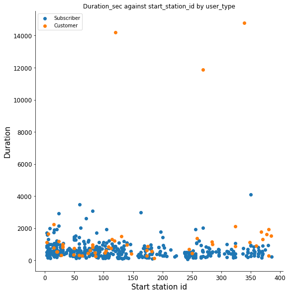

### Start stations vs Time of the day by bike_share_for_all_trip

Start station may be having an effect on if the user shares the bike during riding period. We could also find out different times of the day when users were more likely to share.

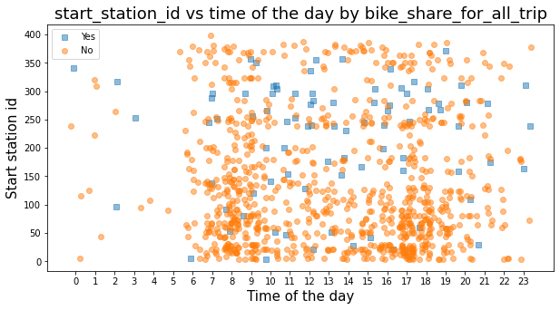

### Duration against bike_id by member_gender

Bike with higher ids are preffered over those with lower ids. For longer durations(the outliers), bikes with higher higher ids were almost always being preffered.

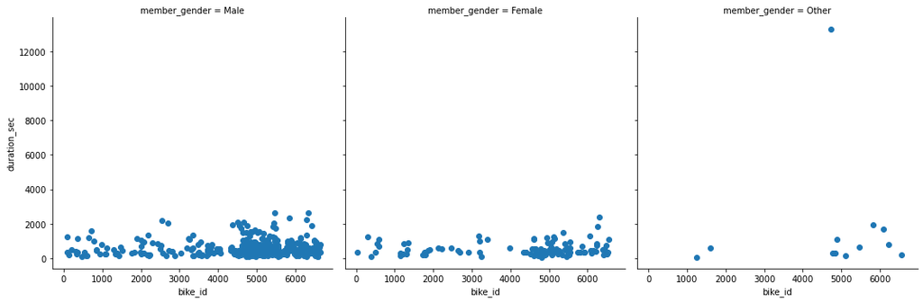

### Distribution of member birth year

Most bike riders are actually millenials(born in between 1980 and 2000). As the age group increases, the count of bike riders decreases.

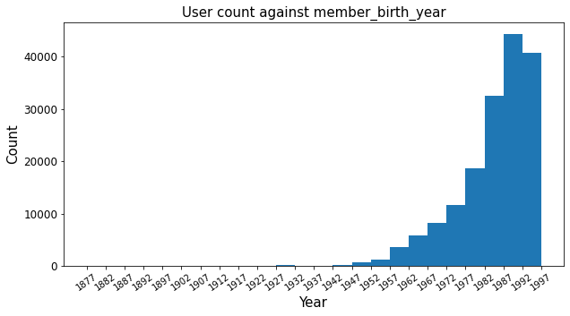